# Biometria

2023-07-31

# Introducción al curso de Biometría

**Instructor:** Raymond L. Tremblay, PhD

**Oficina**: NL 104  
**Teléfono**: (787) 850-9497 (dept de biología)  
**Coreo electronico**: raymond.tremblay_at_upr_dot_edu

### Horario de clase

**Hora de consulta con Estudiantes**:

- L & W 9:00 - 10:30
- L & W 1:00 - 4:30
- J 1:00 - 2:00

## Libro obligatorio.

Aquí dos sitios donde pueden conseguir el libro

- [Havel et al - Introductory Biological Statistics, 4 edition](https://www.amazon.com/Introductory-Biological-Statistics-Fourth-Havel/dp/1478638184/ref=sr_1_1?dchild=1&keywords=Introductory+Biological+Statistics&qid=1594323793&s=books&sr=1-1)
- [Havel et al - Introductory Biological Statistics, 4 edition](https://www.vitalsource.com/referral?term=9781478639282)

### Libros sugeridos

- [Garrett Grolemund, Hadley Wickham. R for Data Science](https://r4ds.had.co.nz) En Ingles.
- [Garrett Grolemund, Hadley Wickham. R para Ciencia de Datos](https://es.r4ds.hadley.nz) En Español.
- [Tremblay y Hernández-Serrano, 2018](https://www.amazon.com/Gráficas-Versátiles-ggplot2-Análisis-Spanish-ebook/dp/B07P2Q87H2/ref=sr_1_1?dchild=1&keywords=Graficas+versatiles&qid=1591404029&sr=8-1).

• Artículos revisados por pares serán asignados para fomentar el método de utilizar estas herramientas en ciencias.

### Programados

- [R- free statistical programming language](https://cran.r-project.org/)
- [RStudio](https://rstudio.com)
- MSExcel, Numbers o Google Sheet

### Prerequisitos

- BIOL 3011-3013: Biología General y Laboratorio primer semestre
- BIOL 3012-3014: Biología General y Laboratorio segundo semestre

### Descripción del curso

Estudio de diferentes técnicas estadísticas con aplicación a la Biología. Se enfatizará en la estadística descriptiva, análisis de regresiones y correlaciones, pruebas de hipótesis paramétricas y no paramétricas y análisis de frecuencias y varianza. Se hará énfasis en los supuestos de las pruebas, para seleccionar cual método estadístico es adecuado para el diseño experimental y la distribución de los datos. Además, se utilizarán las computadoras como mecanismos para facilitar y agilizar el cómputo y análisis estadístico.

### Objetivos del curso

Al finalizar el curso el estudiante podrá:

1. Discutir la importancia de la estadística en los estudios biológicos.
2. Ordenar datos biológicos en forma lógica.
3. Diferenciar entre los diferentes tipos de datos biológicos.
4. Diferenciar los diferentes tipos de escalas biológicas.
5. Organizar y resumir datos en forma de tablas.
6. Confeccionar polígonos de frecuencia.
7. Creación de gráficas para demostrar patrones.
8. Hacer uso adecuado de las diferentes estadísticas descriptivas.
9. Describir las diferentes medidas de tendencia central.
10. Basado en las medidas de tendencia central, inferir algunas de las características de la muestra bajo estudio.
11. Determinar cuándo se deben calcular en forma grupal las medidas de tendencia central y dispersión de la muestra.
12. Calcular probabilidades en situaciones específicas.
13. Establecer la diferencia entre distribuciones discretas y continuas.
14. Formular una hipótesis nula y alterna, adecuada para una situación en particular.
15. Distinguir de acuerdo al tipo de datos recolectados cuándo utilizar pruebas paramétricas o pruebas no paramétricas.
16. Evaluar los supuestos de las pruebas, tal como distribución normal e igualdad de varianza
17. Evaluar la hipótesis nula y determinar el grado de significación de esta hipótesis haciendo uso de los diferentes análisis estadísticos.
18. Confeccionar tablas de contingencia y establecer homogeneidad.
19. Determinar cuándo se debe utilizar un análisis de regresión.
20. Calcular coeficientes de regresión.
21. Determinar intervalos de confianza y significación de una regresión.
22. Calcular el coeficiente de correlación.
23. Realizar comparaciones entre coeficientes de correlación simples.
24. Desarrollar y analizar diseños experimentales utilizando técnicas de muestreo y recolección de datos apropiados.
25. Determinar el error de muestra.
26. Conocer y aplicar las pruebas básicas en estadísticas.
27. Evaluar situaciones experimentales y poder desarrollar un diseño experimental adecuado y lógico para analizar el problema y llegar a conclusiones.
28. Se hará énfasis en el uso de programados estadísticos para calcular los índices y probar hipótesis. Los programa de computadora puede incluir R.

### Puntuacion:

Este curso sera evaluado con los siguiente items:

| Item | Valor |
| --- | --- |
| Ejercicios práctico (4-6 total) | 30% |
| Pruebas cortas (una por semana) | 15% |
| Participación | 10% |
| Examen parcial # 1 (fecha TBD) | 15% |
| Examen parcial # 2 (fecha TBD) | 15% |
| Examen Final (fecha TBD) | 10% |

NOTE: Escala de Notas:

- A (100 to 90)
- B (89 to 80)
- C (79 to 70)
- D (69 to 60)
- F (< 60)

### Examenes:

Habrá dos examen parciales y un examen final *comprensivo*. Estos exámenes serán de selecciones múltiples, pareo, respuesta corta, y análisis de conceptos. El examen final será comprensivo (incluye todos los temas del semestre). En este examen final se hará énfasis en la comprensión y aplicaciones de los supuestos de las pruebas y la capacidad de seleccionar la prueba correcta basado en el diseño experimental y los supuestos.

Si el examen es vitrual es obligatorio tener la camera prendida durante **todo el exámen**. No es permitido usar el celular, Ud. tendrá que demostrar que el celular este detrás de uds antes de comenzar el examen

### Conferencias

En la clase las notas serán basado primeramente en la participación y algunas pruebas cortas. Su participación es esencial para el aprendizaje (y para un ambiente positivo). Aprender *NO* es un proceso pasivo: los estudiantes deben participar haciendo preguntas y discutir el material con su conocimiento anterior (Su bagaje de conocimiento).

### Ejercicios

Los ejercicios están enfocado en la aplicación de conceptos y métodos discutido en la clase y solución de problemas. Se hará un esfuerza de usar datos reales para demostrar como trabajar con los análisis, tablas, y gráficos en R, RStudio y RMarkdown. Típicamente, tendrán solamente una semana para hacer los ejercicios y entregarlos en formato *.html*.

### Faltar a clase y examen:

*Los trabajos cortos y pruebas cortas NO se reponen*. Si falta a la clase es su responsabilidad hablar con los otros estudiantes para saber lo que se discutió en la clase. Los examen se reponen solamente por una escusa valida.

### Derechos de Estudiantes con Impedimentos

La UPR-Humacao cumple con las leyes ADA (Americans with Disabilities Act) y 51 (Servicios Educativos Integrales para Personas con Impedimentos) para garantizar igualdad en el acceso a la educación y servicios. Estudiantes con impedimentos: informe al (la) profesor(a) de cada curso sobre sus necesidades especiales y/o de acomodo razonable para el curso, en la tarjeta de información de la primera semana y visite la Oficina de Servicios para la Población con Impedimentos (SERPI) a la brevedad posible. Se mantendrá la confidencialidad.

### Integridad academica

La Universidad de Puerto Rico promueve los más altos estándares de integridad académica y científica. El Artículo 6.2 del Reglamento General de Estudiantes de la Universidad de Puerto Rico (Certificación Núm. 13, 2009-2010, de la Junta de Síndicos) establece que la deshonestidad académica incluye, pero no se limita a: acciones fraudulentas, la obtención de notas o grados académicos valiéndose de falsas o fraudulentas simulaciones, copiar total o parcialmente la labor académica de otra persona, plagiar total o parcialmente el trabajo de otra persona, copiar total o parcialmente las respuestas de otra persona a las preguntas de un examen, haciendo o consiguiendo que otro tome en su nombre cualquier prueba o examen oral o escrito, así como la ayuda o facilitación para que otra persona incurra en la referida conducta. Cualquiera de estas acciones estará sujeta a sanciones disciplinarias en conformidad con el procedimiento disciplinario establecido en el Reglamento General de Estudiantes de la UPR vigente.

### Comentario sobre grabar videos y/o audio de las clases

Los estudiantes no PUEDEN grabar la clase por forma de video o audio sin el permiso del profesor. Algunos estudiantes con necesidades especiales pueden hablar con el profesor para pedir el permiso. La solicitud y aprobación del permiso tiene que ser por escrito (por ejemplo por email).

### Espacio libre de acoso sexual

La Universidad de Puerto Rico prohíbe el descrimen por razón de sexo y género en todas sus modalidades, incluyendo el hostigamiento sexual. Según la Política Institucional contra el hostigamiento sexual, en la Universidad de Puerto Rico, Cert. Núm. 130 (2014-2015) de la Junta de Gobierno, si un(a) estudiante está siendo o fue afectado por conductas relacionadas a hostigamiento sexual, puede acudir ante la Oficina del Procurador Estudiantil, el Decanato de Estudiantes o el Coordinador de Cumplimiento con Título IX para una orientación o presentar una querella.

### Protocolo de la Clase

Los teléfonos mobiles serán apagado durante la clase. Si necesita una calculadora traerla al salón. El teléfono no debería esta visible durante la clase al menos que pide permiso al instructor. Recuerda que que se usara computadoras portátiles en cada sesión.

# Introducción a la Biometria

[figure not shown]

[figure not shown]

## El libro de la clase

[Introductory Biological Statistics by Havel, Hampton and Meiners](https://www.amazon.com/Introductory-Biological-Statistics-Fourth-Havel/dp/1478638184/ref=sr_1_1?dchild=1&keywords=Introductory+Biological+Statistics&qid=1594323793&s=books&sr=1-1) Presione en el titulo para dirigirlo a Amazon.

Fecha de la ultima revisión

```
## [1] "2023-07-31"
```

## El proceso de investigación:

En este curso se estará enfatizando los análisis cuantitativo, esto es simplemente que analizamos los datos para llegar a una conclusión o interpretación sobre un tema. Naturalmente el proceso de seleccionar los datos puede ser un reto grande. Como uno selecciona los datos y el desarrollo de la investigación depende del diseño experimental. El diseño es el procedimiento de como uno recolecta los datos y como los vamos a analizar. En este curso no estaremos evaluando métodos cualitativos de análisis. Este método cuantitativo se refiere a evaluar principalmente opiniones, motivaciones o razones que influencia o impacta una situación. En los métodos cuantitativos es necesario que los resultados sean de una forma o otra numéricos o categóricos.

El proceso de investigación cuantitativo tiene múltiples pasos y podemos visualizar los pasos con un diagrama de flujo.

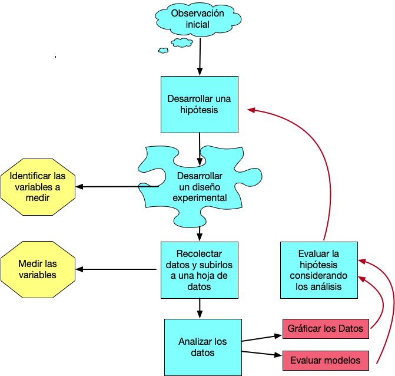

El proceso de Investigación

## El primer paso:

1. Todo comienza con una pregunta que te llama la intención. Esta pregunta proviene de haber observado tu ambiente. Puede que sea algo muy sencillo (por ejemplo: si la cantidad de estudiantes por salón impacta su rendimiento), o puede ser una pregunta más complicada (por ejemplo cual es el impacto de la lactancia sobre el desarrollo de las células, la bioquímica y inteligencia de los niños).

## El segundo paso

2. El próximo paso es desarrollar una hipótesis. Hay dos tipos de hipótesis, la hipótesis nula y la hipótesis alterna. SIEMPRE uno comprueba la hipótesis NULA. La nula en la en forma más sencilla es que los grupos son iguales. En otra palabra, si regresamos a la pregunta del primer paso, el rendimiento de los estudiantes es irrelevante de la cantidad de estudiantes en el salón en otra palabra es igual si hay pocos o muchos estudiantes. La hipótesis alterna es que “que la cantidad de estudiante en un salón impacta el rendimiento de los estudiantes”. Hay otros tipos de hipótesis nula que veremos más tarde.
- Si se acepta la hipótesis nula esto quiere decir que NO hay evidencia que los grupos sean diferentes.
- Si se rechaza la hipótesis nula es que hay evidencia que los dos grupos sean diferentes.

## El tercer paso:

3. Ahora hay que definir cual son las variables (datos) que se van a recolectar para evaluar la hipótesis. Por ejemplo, cuantos grupos de estudiantes se seleccionará (2, 3, 10 salones?), La información se recolectará de cuantos estudiantes por salones (todos, la mitad, los que se aparece, o se seleccionará los estudiantes al azar, y si selecciona al azar cual es el mecanismo para seleccionarlos de esta forma). Cual sera el indice de “rendimiento” (el entusiasmo de cada estudiante, la nota de un examen, de un trabajo, la nota final). Si se selecciona la nota final la información sera la nota numérica o alfabética (A, B, C, D, o F).

Tomando la información anterior en consideración esto determinará el diseño experimental y las pruebas estadísticas que se deberá utiliza en el quinto paso.

## El cuarto paso:

4. Recolectar los datos. Este se debe hacer de una forma sistemática, con la información bien apuntado y subir la información en una hoja de calculo (spreadsheet), como MS Excel, Google Sheet y Numbers. Es mi sugerencia de **NUNCA** utilizar un programa como SPSS o JMP para poner los datos, ya que con estos programas si en el futuro se quiere tener acceso a los datos, y no tiene el programado o el programado ha cambiado de versión muchas veces los datos no se pueden leer (experiencia personal).

## El quinto paso:

5. En este paso se hará los gráficos y los análisis estadísticos para evaluar la hipótesis.

## El sexto paso:

6. Aceptar o rechazar la hipótesis NULA.

## Tipo de error de interpretación en estadística

El concepto básico en estadística, y probablemente el más difícil a captar para algunos es que en el mundo existe la *verdad*, pero cuando uno recolecta datos, no necesariamente los datos de la muestra representa la *verdad* o sea la realidad. Por consecuencia siempre hay una posibilidad que los datos nos engaña, y si nos engaña estamos haciendo un error en rechazar o aceptar la hipótesis nula. Por consecuencia aun que uno tome todas las precauciones para tener un diseño experimental adecuado es posible que los datos no representan el universo de los datos (la verdad).

Típicamente se rechaza la hipótesis nula si el valor de **p** es menor de 0.05. No es necesario que el valor sea menor de 0.05 para rechazar la hipótesis, en cierta condiciones el valor crítico pudiese ser mayor o menor de 0.05. El valor de **p** represente la probabilidad de rechazar la hipótesis nula cuando se debería aceptar. Por consecuencia un valor de **p** = 0.05, significa que hay 5% de probabilidad de cometer un error en que rechazamos la hipótesis cuando se debería aceptar si repetimos la investigación 100 veces (una razón de 1:20). Entonces este representa un tipo de error posible, frecuentemente nominado tipo de error 1 o alfa. En otra palabras significa la probabilidad de rechazar la hipótesis cuando uno debería aceptar la hipótesis. El otro tipo de error 2 o beta representa el error de aceptar la hipótesis nula cuando se debería rechazar.

Los tres términos usado en estadística para de los dos tipos de errores

- Tipo de error I, alfa, falso positivos
- Tipo de error II, beta, falso negativos

Aquí un gráfico de los tipos de errores. El par de gráficos representa los dos tipos de error y las dos condiciones en que no se hace un error.

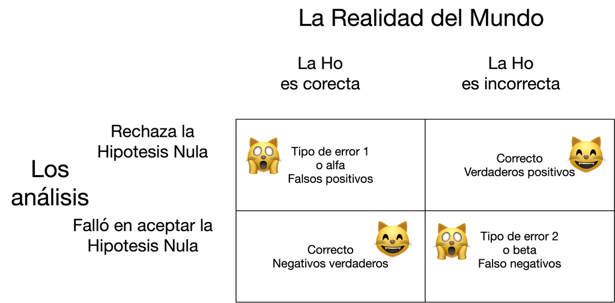

Ahora vamos a considerar un ejemplo básico de preguntas que se podría evaluar. En este tiempo moderno un tipo de programas a la televisión bien común son los “Reality Shows”. Donde típicamente participa individuos supuestamente “normal” que no sean actores profesionales. Aquí una lista de algunos de los “Reality Shows”.

### Consideramos los Reality Shows:

- Kardashians
- The Bachelorette
- Survivors
- Big Brother
- Shark Tank
- Skin Wars
- Hell’s Kitchen

### Personalidad de las personas

Uno se podría preguntar que tipo de persona son seleccionado para participar en estos tipos de programas. Una hipótesis que son gente con tipo de personalidad bien específica. Una hipótesis es que son gente que cumple con unas características tal como *Trastorno de personalidad narcisista* (TPN): estas personas de vez en cuando caracterizado como megalomanía, demuestran un patrón a largo plazo de comportamiento anormal caracterizado por sentimientos exagerados de importancia personal, necesidad excesiva de admiración y falta de empatía.

En un ejemplo de **Field et al. 2014** se demuestra la siguiente información sobre personas que solicitaron ser parte de uno de estos *Reality Show* que se llama *Big Brother*.

Una hipótesis es que los productores de estos *Reality Shows* seleccionan gente con características de TPN más a menudo que las gente que no tienen esta condición. Podemos comprobar esto recolectando datos de los que solicitan y los que fueron aceptado o no a participar en Big Brother (United Kingdom). Se entrevistaron 7662 personas para seleccionar 12, a cada uno se le hizo una prueba si tenia síntomas de TPN.  
***

|  | No TNP | TPN | Total |
| --- | --- | --- | --- |
| Seleccionado | 3 | 9 | 12 |
| Rechazado | 6805 | 845 | 7650 |
| Total | 6808 | 854 | 7662 |

Lo que uno observa es que la gente que son identificado que tiene características que cumple con TPN son más propenso a ser seleccionado para participar en el programa. Si fuese que la selección hubiese sido al azar, uno esperaría solamente 1 o 2 personas al máximo con la condición de TPN, no 9 personas. Más tarde aprenderemos como calcular el valor esperado exacto.

## Cuando que una hipótesis no es una hipótesis?

### Una hipótesis tiene que ser falsificable

Esto quiere decir hay que tener un mecanismo para determinar la veracidad de una expresión. Por ejemplo en las 4 expresiones siguiente hay 2 que no pueden ser falsificable. El concepto de hipótesis falsificable proviene del filósofo Karl Popper en su libro *Logik der Forschung* (1934), traducido al español **La lógica de la investigación científica**. Ahora toma el tiempo de evaluar las siguientes expresiones y trate de determinar si son hipótesis falsificable. Desafortunademente, en el vocabulario popular el términos hipótesis y teoría se usan para describir cualquier pensamiento que la gente QUISIERA que se verídico. También se hace hipótesis o mejor dicho expresiones que no son falsificable. En nuestra sociedad donde cualquier persona se puede llamar un periodista y especialista en un tema los comentarios no falsificable dominan y resulta en confusión para la gente. Es importante en ciencia que los temas, las áreas de investigación sean falsificable.

### Ejercicio 1

- Lin Manuel es el mejor actor del mundo
- Todos la cisnes son blancos
- El aumento en producción de semillas en una planta X aumenta con el tamaño poblacional de esta especie.
- Los Beatles vendieron más discos que cualquier otro grupo artístico.

### Evaluación de las expresiones falsificables

- Lin Manuel es el mejor actor del mundo.

  Esta expresión no es una hipótesis falsificable porque el concepto de **mejor** es uno que es basado en un juicio individual. En otra palabra como se mide “**mejor**, y quien toma la decisión sobre este medida cualitativa. Si Ud. proviene de una cultura diferente la apreciación a la música cambia drasticamente.
- Todos los cisnes son blancos

  El problema con esta expresión es la palabra “Todos”. En ningún momento aun que uno trate nunca se podría encontrar “Todos” los cisnes para evaluar sin son blancos o no. Por consecuencia no es falsificable. El concepto de “Todos” aquí asume que ni uno no sera evaluado, que es imposible.
- El aumento en producción de semillas en una planta X aumenta el tamaño poblacional de esta especie.

  Este es una hipótesis falsificable por que uno puede hacer un experimento para evaluar la relación que hay entre la producción de semillas y el tamaño poblacional de una especie de plantas.
- Los Beatles vendieron más discos que cualquier otro grupo artístico.

  Este es una hipótesis falsificable porque se puede contabilizar la cantidad de discos vendidos por los Beatles y otros grupos y determinar si es cierto o no.

## Variables Independientes y Dependientes

-La variable Independiente: es la variable que impacta (teóricamente) la variable dependiente (puede ser que no impacta el resultado). Típicamente la **x** en un modelo es la variable independiente.

-La variable Dependiente: es la variable que recibe el efecto (teóricamente) de la variable independiente. La variable dependiente depende de la variable independiente. Las **y’s** en un modelo son las variables dependientes.

## Niveles de mediciones

### Variables continuas

- Las variables con datos continuos:
  - Son valores que son contiguos o por lo menos existe o pudiese existir los valores intermedios.
  - Ejemplo 1
  - la distancia entre el valor 13 y 15 es igual que 101 y 103, hay dos unidades que los separa.
  - Aunque no se haya observado el 14 ni el 102 en un recogido de datos estos valores tienen potencialmente existir, en otra palabra estos valores son posibles en el universo de los datos.
  - Ejemplo 2
    - Si se mide el tamaño de una célula biológicas en micrómetros (µm, $10^{-6}$). Los valores intermedios y contiguos existen. Por ejemplo, el largo de las células de *Escherichia coli* (*E. coli*) adulta son de 5.27µm en promedio con una desviación estándar de 0.87µm. Esto significa que hay células de diferentes tamaños que van de menos de 2µm a más de 10µm de largo, y todos los valores pueden existir en este rango (ref: https://doi.org/10.1098/rsos.160417). Más tarde veremos como se puede llagar a la conclusión que las células varían entre 2µm a más de 10µm de largo, cuando uno tiene solamente el promedio y la desviación estándar.

  Ejemplo 3
  - El número de hermanos, si por ejemplo yo pregunto a seis estudiantes cuantos hermanos tiene. Yo podría tener la siguiente lista. Aunque que no hubo ningún estudiante que tenga 1 hermano o 6 hermanos, es posible esta alternativas. Note algo especial aquí es que nadie puede tener 2.4 hermanos, los valores tienen que ser números enteros. Cuando son conteos así, la distribución de los datos provienen frecuentemente de una distribución **Poisson** (veremos más tarde).
  - Números de hermanos (0, 2, 5, 3, 8, 4)

### Varriables Discretas

- Categórica o Discreta
  - Variables Nominales]
    - Hombres y Mujeres
    - Omnívoro, vegetariano, vegano, carnívoro
- Variable Ordinal
  - Datos donde hay un orden en los valores
    - primero, segundo, tercero, etc.
    - A, B, C, D, F (nota de estudiantes)
- Variable Binomio
  - Tiene solamente dos alternativas
    - Vivo o muerto
    - Vive en PR o No vive en PR
    - Esta embrazada o No esta embarazada

# Nombre del capitulo.

All chapters start with a first-level heading followed by your chapter title, like the line above. There should be only one first-level heading (`#`) per .Rmd file.

## Otra seccion

All chapter sections start with a second-level (`##`) or higher heading followed by your section title, like the sections above and below here. You can have as many as you want within a chapter.

### A subsection

The subtopic

More subdivision

Even more subdivision

### An unnumbered section

Chapters and sections are numbered by default. To un-number a heading, add a `{.unnumbered}` or the shorter `{-}` at the end of the heading, like in this section.

Remember not to use only 1 *#* as this indicates a new chapter

## NOTE the size of font changes with the number *#*

### NOTE the size of font changes with the number *#*

#### NOTE the size of font changes with the number *#*

##### NOTE the size of font changes with the number *#*

# Cross-references

Cross-references make it easier for your readers to find and link to elements in your book.

## Captioned figures and tables

Figures and tables *with captions* can also be cross-referenced from elsewhere in your book using `\@ref(fig:chunk-label)` and `\@ref(tab:chunk-label)`, respectively.

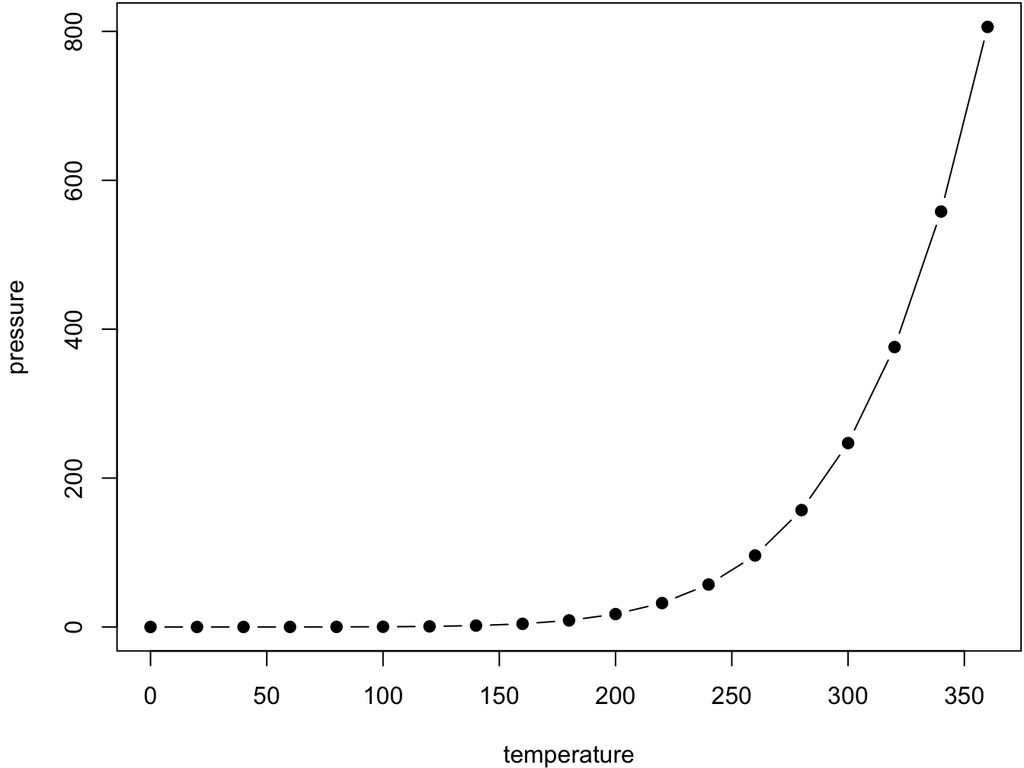

Here is a nice figure!

```r
par(mar = c(4, 4, .1, .1))
plot(pressure, type = 'b', pch = 19)
```

```r
knitr::kable(
  head(pressure, 10), caption = 'Here is a nice table!',
  booktabs = TRUE
)
```

Here is a nice table!

| temperature | pressure |
| --- | --- |
| 0 | 0.0002 |
| 20 | 0.0012 |
| 40 | 0.0060 |
| 60 | 0.0300 |
| 80 | 0.0900 |
| 100 | 0.2700 |
| 120 | 0.7500 |
| 140 | 1.8500 |
| 160 | 4.2000 |
| 180 | 8.8000 |